# Chapter code for Applied Predictive Modeling (Kuhn and Johnson, 2013)

Chapter 6

by Brian Hassett

# 6 Linear Regression and Its Cousins

This is a `tidymodels` implementation of the code in **Chapter 6** of **Applied Predictive Modeling** by Max Kuhn and Kjell Johnson[^1]. I have already implemented all code and models from this chapter using mainly the `caret` package in a separate notebook, `APM_6.Rmd`. In that notebook I used the `solTrainXtrans` data set as the training data. This data set has already had a transformation applied to it (Box-Cox). In this notebook I have used the full data set (un-transformed) and did the Box-Cox transformation and data splitting myself using the appropriate recipe.

## Setup

```r
# Load packages:
library(AppliedPredictiveModeling)
library(caret)
library(tidyverse)
library(tidymodels)
library(patchwork)

# Load my functions:
source("/home/brian/R/dir/Util/bh_functions.R")

# Options:
theme_set(theme_bw())
options(digits = 4)
```

## Load and Split Data

The `tidymodels` process has its own functions for splitting data. Combine the pre-split training and test data from the `solubility` data into one data frame, then use the `tidymodels` functions to split the data:

```r
# Load data:
data(solubility)

# Combine the data sets (update the name of the outcome vectors to y so that they are the same).
# Also give the data frame a generic name.
df1 <- rbind(
  cbind(y = solTrainY, solTrainX), # training data
  cbind(y = solTestY, solTestX) # test data
)

# Split data:
set.seed(1)
splits <- initial_split(df1) # default prop is 3/4
df_train <- training(splits)
df_test <- testing((splits))

# Create folds for 10-fold cross-validation:
folds <- vfold_cv(df_train, v = 10)
```

## Data Summary

No missing data, and all variables are numeric:

```r
bh_print_data_summary(df1)
```

```
                      [,1]
num_rows              "  1,267"
num_cols              "    229"
num_categorical_cols  "      0"
num_numeric_cols      "    229"
all_missing_cols      "      0"
complete_cols         "    229"
total_missing         "      0"
total_percent_missing "      0"
total_data_points     "290,143"
size_MB               "      1"
```

## Distribution of outcome variable

The outcome variable is not too skewed:

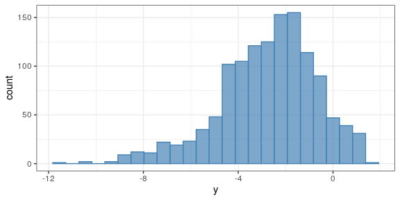

```r
df1 %>%
  ggplot() +
  geom_histogram(aes(y), bins = 25,
                 fill = "steelblue", color = "steelblue", alpha = 0.7)
```

## 6.1 Linear Regression

### Training Data

Build a linear regression model and evaluate using cross-validation:

```r
# Recipe:
rec1 <-
  recipe(y ~ ., data = df_train) %>%
  step_center(all_predictors()) %>%
  step_scale(all_predictors()) %>%
  step_BoxCox(all_numeric(), -all_outcomes()) %>%
  step_nzv(all_predictors()) %>%
  step_corr(all_predictors(), -all_outcomes(),
            threshold = 0.9) # same threshold as used in the APM text, but they say it might be a bit high

# Model:
lm_mod <-
  linear_reg() %>%
  set_engine("lm")

# Workflow:
workflow1 <-
  workflow() %>%
  add_model(spec = lm_mod) %>%
  add_recipe(recipe = rec1)

# Use `tune::fit_resamples()` to combine the workflow and CV folds to fit the model on the training data:
## Read in cached results if available:
file1 <- "/home/brian/R/dir/APM/chapter6/models/lm_fit.RDS"
if (file.exists(file1)) {
  lm_fit <- readRDS(file1)
} else {
  lm_fit <-
    workflow1 %>%
    fit_resamples(folds)
  saveRDS(lm_fit, file1)
}
```

View metrics and store the training error:

```r
collect_metrics(lm_fit)
```

| .metric | .estimator | mean | n | std_err | .config |
| --- | --- | --- | --- | --- | --- |
| rmse | standard | 0.7325 | 10 | 0.02633 | Preprocessor1_Model1 |
| rsq | standard | 0.8736 | 10 | 0.01129 | Preprocessor1_Model1 |

```r
rmse_train <- lm_fit %>%
  collect_metrics() %>%
  filter(.metric == "rmse") %>%
  pluck("mean", 1)
```

### Testing Data

Fit a model using all of the training data and apply it to the test data:

```r
# Final fit:
lm_fit_final <-
  workflow1 %>%
  last_fit(splits)

rmse_test <- lm_fit_final %>%
  collect_metrics() %>%
  filter(.metric == "rmse") %>%
  pluck(".estimate", 1)
```

Store the training and test RMSE values and parameters:

```r
RMSE_TM <- tibble(
  framework = "tidymodels",
  engine = "lm",
  model = "Linear Regression",
  rmse_train = rmse_train,
  rmse_test = rmse_test,
  parameters = NA_character_)
```

### Use the predictions to make diagnostic plots

Collect the predictions from the final fit and make diagnostic plots:

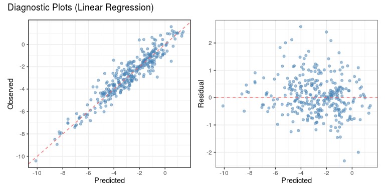

```r
preds <- lm_fit_final %>%
  collect_predictions() %>%
  mutate(residual = y - .pred)

p1 <- ggplot(preds) +
  geom_point(aes(.pred, y),
             color = "steelblue", alpha = 0.5) +
  geom_abline(color = "indianred1", linetype = "dashed") +
  scale_x_continuous("Predicted",
                     breaks = seq(-10, 0, by = 2)) +
  scale_y_continuous("Observed",
                     breaks = seq(-10, 0, by = 2))

p2 <- ggplot(preds) +
  geom_point(aes(.pred, residual),
             color = "steelblue", alpha = 0.5) +
  geom_hline(yintercept = 0,
             color = "indianred1", linetype = "dashed") +
  scale_x_continuous("Predicted",
                     breaks = seq(-10, 0, by = 2)) +
  scale_y_continuous("Residual")

p1 + p2 + plot_annotation(title = "Diagnostic Plots (Linear Regression)")
```

The plots look similar to the results obtained using the `caret` workflow in `APM_6.Rmd`.

## 6.2 Partial Least Squares (PLS)

### Training Data

Build a PLS model and train using cross-validation.

Use the same preprocessing recipe as used with linear regression.

```r
# Model:
pls_mod <-
  plsmod::pls(num_comp = tune(), predictor_prop = 1) %>% # 1 = use all predictors
  set_mode("regression") %>%
  set_engine("mixOmics")

# Workflow:
workflow2 <-
  workflow() %>%
  add_model(spec = pls_mod) %>%
  add_recipe(recipe = rec1)

# Tuning grid:
pls_grid <- data.frame(num_comp = seq(1, 49, 2))

# Use `tune::tune_grid()` to combine the workflow and CV folds to fit the model on the training data:
## Read in cached results if available:
file1 <- "/home/brian/R/dir/APM/chapter6/models/pls_cv.RDS"
if (file.exists(file1)) {
  pls_cv <- readRDS(file1)
} else {
  pls_cv <-
    workflow2 %>%
    tune_grid(resamples = folds,
              grid = pls_grid,
              control = control_grid(save_pred = TRUE),
              metrics = metric_set(rmse, rsq))
  saveRDS(pls_cv, file1)
}
```

Plot CV results:

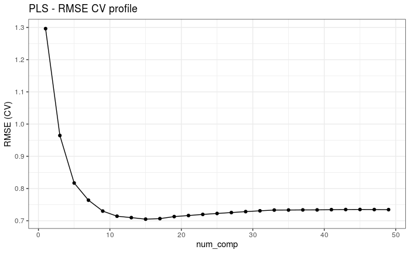

```r
pls_cv %>%
  collect_metrics() %>%
  filter(.metric == "rmse") %>%
  ggplot(aes(num_comp, mean)) +
  geom_point() +
  geom_line() +
  labs(y = "RMSE (CV)", title = "PLS - RMSE CV profile")
```

Select the best model and store the training error:

```r
pls_best <- pls_cv %>%
  select_best("rmse")

# Store the training error:
rmse_train <- pls_cv %>%
  show_best("rmse") %>%
  pluck("mean", 1)
```

### Testing Data

Fit a model using all of the training data and apply it to the test data:

```r
# Finalize the workflow by updating it to use the best model:
final_wf <-
  workflow2 %>%
  finalize_workflow(pls_best)

# This extracts the parameters in the final model (this code is clunky, could probably be made simpler):
wf <- final_wf %>% workflows::pull_workflow_spec()
num_comp <- wf$args$num_comp[2] %>% as.character()
```

```
Subsetting quosures with `[` is deprecated as of rlang 0.4.0
Please use `quo_get_expr()` instead.
```

```r
# Fit the final model using all of the training data and evaluate using the test data:
pls_fit_final <-
  final_wf %>%
  last_fit(splits)

# Store test error:
rmse_test <- pls_fit_final %>%
  collect_metrics() %>%
  filter(.metric == "rmse") %>%
  pluck(".estimate")
```

Store the training and test RMSE values and parameters:

```r
RMSE_TM <- rbind(RMSE_TM,
                 c(framework = "tidymodels",
                   engine = "mixOmics",
                   model = "PLS",
                   rmse_train = rmse_train,
                   rmse_test = rmse_test,
                   parameters = str_interp("num_comp: ${num_comp}")))
```

### Use the predictions to make diagnostic plots

Collect the predictions from the final fit and make diagnostic plots:

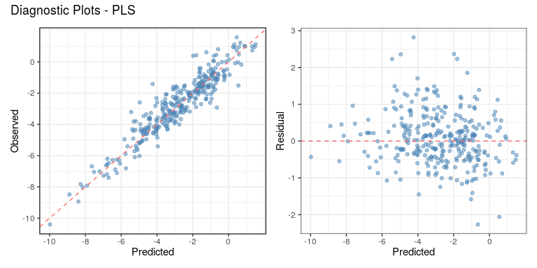

```r
preds <- pls_fit_final %>%
  collect_predictions() %>%
  mutate(residual = y - .pred)

p1 <- ggplot(preds) +
  geom_point(aes(.pred, y),
             color = "steelblue", alpha = 0.5) +
  geom_abline(color = "indianred1", linetype = "dashed") +
  scale_x_continuous("Predicted",
                     breaks = seq(-10, 0, by = 2)) +
  scale_y_continuous("Observed",
                     breaks = seq(-10, 0, by = 2))

p2 <- ggplot(preds) +
  geom_point(aes(.pred, residual),
             color = "steelblue", alpha = 0.5) +
  geom_hline(yintercept = 0,
             color = "indianred1", linetype = "dashed") +
  scale_x_continuous("Predicted",
                     breaks = seq(-10, 0, by = 2)) +
  scale_y_continuous("Residual")

p1 + p2 + plot_annotation(title = "Diagnostic Plots - PLS")
```

## 6.3 Penalized Models

### Training Data

Build a ridge regression model and train using cross-validation.

```r
# Recipe:
rec3.1 <-
  recipe(y ~ ., data = df_train) %>%
  step_BoxCox(all_numeric(), -all_outcomes()) %>%
  step_nzv(all_predictors()) %>%
  step_center(all_predictors()) %>%
  step_scale(all_predictors())

# Model:
# We will use tune() to find the `penalty` value. Setting `mixture` to 0 gives ridge regression.
rr_mod <-
  linear_reg(penalty = tune(), mixture = 0) %>%
  set_mode("regression") %>%
  set_engine("glmnet")

# Workflow:
workflow3.1 <-
  workflow() %>%
  add_model(spec = rr_mod) %>%
  add_recipe(recipe = rec3.1)

# Tuning grid:
rr_reg_grid <- tibble(penalty = 10^seq(-4, 0.5, length.out = 25))

# Use `tune::tune_grid()` to combine the workflow and CV folds to fit the model on the training data:
## Read in cached results if available:
file1 <- "/home/brian/R/dir/APM/chapter6/models/rr_cv.RDS"
if (file.exists(file1)) {
  rr_cv <- readRDS(file1)
} else {
  rr_cv <-
    workflow3.1 %>%
    tune_grid(resamples = folds,
              grid = rr_reg_grid,
              control = control_grid(save_pred = TRUE),
              metrics = metric_set(rmse, rsq))
  saveRDS(rr_cv, file1)
}
```

Plot CV results:

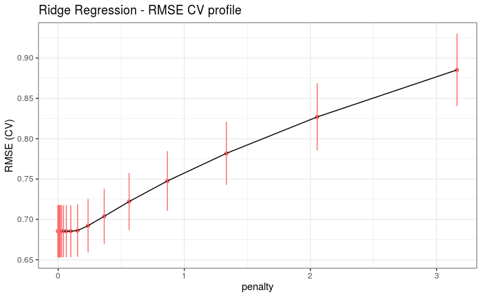

```r
rr_cv %>%
  collect_metrics() %>%
  filter(.metric == "rmse") %>%
  ggplot(aes(penalty, mean)) +
  geom_point(color = "indianred1") +
  geom_line() +
  geom_errorbar(aes(ymin = mean - 2*std_err, ymax = mean + 2*std_err),
                  color = "indianred1") +
  labs(y = "RMSE (CV)", title = "Ridge Regression - RMSE CV profile")
```

The error is constant for low values of `penalty` before increasing for larger values.

Select the best model and store the training error:

```r
rr_best <- rr_cv %>%
  select_best("rmse")

# Store the training error:
rmse_train <- rr_cv %>%
  show_best("rmse") %>%
  pluck("mean", 1)
```

### Testing Data

Fit a model using all of the training data and apply it to the test data:

```r
# Finalize the workflow by updating it to use the best model:
final_wf <-
  workflow3.1 %>%
  finalize_workflow(rr_best)

# This extracts the parameters in the final model (this code is clunky, could probably be made simpler):
wf <- final_wf %>% workflows::pull_workflow_spec()
penalty <- wf$args$penalty[2] %>% as.character()

# Fit the final model using all of the training data and evaluate using the test data:
rr_fit_final <-
  final_wf %>%
  last_fit(splits)

# Store test error:
rmse_test <- rr_fit_final %>%
  collect_metrics() %>%
  filter(.metric == "rmse") %>%
  pluck(".estimate")
```

Store the training and test RMSE values and parameters:

```r
RMSE_TM <- rbind(RMSE_TM,
                 c(framework = "tidymodels",
                   engine = "glmnet",
                   model = "Ridge Regression",
                   rmse_train = rmse_train,
                   rmse_test = rmse_test,
                   parameters = str_interp("penalty: ${penalty}")))
```

### Use the predictions to make diagnostic plots

Collect the predictions from the final fit and make diagnostic plots:

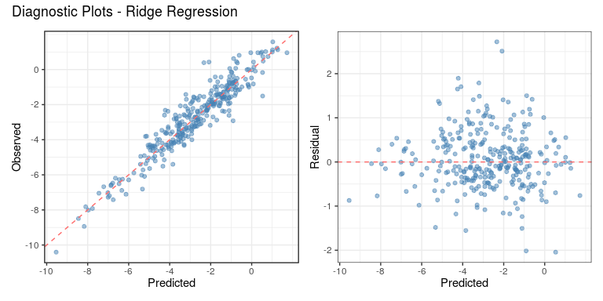

```r
preds <- rr_fit_final %>%
  collect_predictions() %>%
  mutate(residual = y - .pred)

p1 <- ggplot(preds) +
  geom_point(aes(.pred, y),
             color = "steelblue", alpha = 0.5) +
  geom_abline(color = "indianred1", linetype = "dashed") +
  scale_x_continuous("Predicted",
                     breaks = seq(-10, 0, by = 2)) +
  scale_y_continuous("Observed",
                     breaks = seq(-10, 0, by = 2))

p2 <- ggplot(preds) +
  geom_point(aes(.pred, residual),
             color = "steelblue", alpha = 0.5) +
  geom_hline(yintercept = 0,
             color = "indianred1", linetype = "dashed") +
  scale_x_continuous("Predicted",
                     breaks = seq(-10, 0, by = 2)) +
  scale_y_continuous("Residual")

p1 + p2 + plot_annotation(title = "Diagnostic Plots - Ridge Regression")
```

### Training Data

Build a lasso model and train using cross-validation.

```r
# Recipe:
rec3.2 <-
  recipe(y ~ ., data = df_train) %>%
  step_BoxCox(all_numeric(), -all_outcomes()) %>%
  step_nzv(all_predictors()) %>%
  step_center(all_predictors()) %>%
  step_scale(all_predictors())

# Model:
# We will use tune() to find the `penalty` value. Setting `mixture` to 1 gives lasso.
lasso_mod <-
  linear_reg(penalty = tune(), mixture = 1) %>%
  set_mode("regression") %>%
  set_engine("glmnet")

# Workflow:
workflow3.2 <-
  workflow() %>%
  add_model(spec = lasso_mod) %>%
  add_recipe(recipe = rec3.2)

# Tuning grid:
lasso_grid <- tibble(penalty = 10^seq(-4, 0.5, length.out = 25))

# Use `tune::tune_grid()` to combine the workflow and CV folds to fit the model on the training data:
## Read in cached results if available:
file1 <- "/home/brian/R/dir/APM/chapter6/models/lasso_cv.RDS"
if (file.exists(file1)) {
  lasso_cv <- readRDS(file1)
} else {
  lasso_cv <-
    workflow3.2 %>%
    tune_grid(resamples = folds,
              grid = lasso_grid,
              control = control_grid(save_pred = TRUE),
              metrics = metric_set(rmse, rsq))
  saveRDS(lasso_cv, file1)
}
```

Plot CV results:

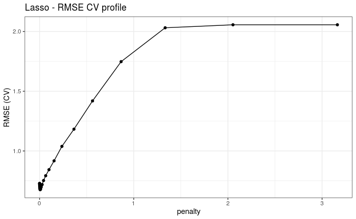

```r
lasso_cv %>%
  collect_metrics() %>%
  filter(.metric == "rmse") %>%
  ggplot(aes(penalty, mean)) +
  geom_point() +
  geom_line() +
  labs(y = "RMSE (CV)", title = "Lasso - RMSE CV profile")
```

The error increases as the `penalty` increases.

Select the best model and store the training error:

```r
lasso_best <- lasso_cv %>%
  select_best("rmse")

# Store the training error:
rmse_train <- lasso_cv %>%
  show_best("rmse") %>%
  pluck("mean", 1)
```

### Testing Data

Fit a model using all of the training data and apply it to the test data:

```r
# Finalize the workflow by updating it to use the best model:
final_wf <-
  workflow3.2 %>%
  finalize_workflow(lasso_best)

# This extracts the parameters in the final model (this code is clunky, could probably be made simpler):
wf <- final_wf %>% workflows::pull_workflow_spec()
penalty <- wf$args$penalty[2] %>% as.character()

# Fit the final model using all of the training data and evaluate using the test data:
lasso_fit_final <-
  final_wf %>%
  last_fit(splits)

# Store test error:
rmse_test <- lasso_fit_final %>%
  collect_metrics() %>%
  filter(.metric == "rmse") %>%
  pluck(".estimate")
```

Store the training and test RMSE values and parameters:

```r
RMSE_TM <- rbind(RMSE_TM,
                 c(framework = "tidymodels",
                   engine = "glmnet",
                   model = "Lasso",
                   rmse_train = rmse_train,
                   rmse_test = rmse_test,
                   parameters = str_interp("penalty: ${penalty}")))
```

### Use the predictions to make diagnostic plots

Collect the predictions from the final fit and make diagnostic plots:

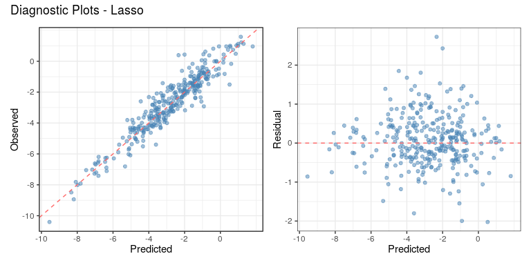

```r
preds <- lasso_fit_final %>%
  collect_predictions() %>%
  mutate(residual = y - .pred)

p1 <- ggplot(preds) +
  geom_point(aes(.pred, y),
             color = "steelblue", alpha = 0.5) +
  geom_abline(color = "indianred1", linetype = "dashed") +
  scale_x_continuous("Predicted",
                     breaks = seq(-10, 0, by = 2)) +
  scale_y_continuous("Observed",
                     breaks = seq(-10, 0, by = 2))

p2 <- ggplot(preds) +
  geom_point(aes(.pred, residual),
             color = "steelblue", alpha = 0.5) +
  geom_hline(yintercept = 0,
             color = "indianred1", linetype = "dashed") +
  scale_x_continuous("Predicted",
                     breaks = seq(-10, 0, by = 2)) +
  scale_y_continuous("Residual")

p1 + p2 + plot_annotation(title = "Diagnostic Plots - Lasso")
```

### Training Data

Build an elastic net model and train using cross-validation.

```r
# Recipe:
rec3.3 <-
  recipe(y ~ ., data = df_train) %>%
  step_BoxCox(all_numeric(), -all_outcomes()) %>%
  step_nzv(all_predictors()) %>%
  step_center(all_predictors()) %>%
  step_scale(all_predictors())

# Model:
# We will use tune() to find the `penalty` and `mixture` values.
enet_mod <-
  linear_reg(penalty = tune(), mixture = tune()) %>%
  set_mode("regression") %>%
  set_engine("glmnet")

# Workflow:
workflow3.3 <-
  workflow() %>%
  add_model(spec = enet_mod) %>%
  add_recipe(recipe = rec3.3)

# Tuning grid:
enet_grid <- expand.grid(penalty = c(0, 0.01, .1),
                         mixture = seq(0.05, 1, length = 20))

# Use `tune::tune_grid()` to combine the workflow and CV folds to fit the model on the training data:
## Read in cached results if available:
file1 <- "/home/brian/R/dir/APM/chapter6/models/enet_cv.RDS"
if (file.exists(file1)) {
  enet_cv <- readRDS(file1)
} else {
  enet_cv <-
    workflow3.3 %>%
    tune_grid(resamples = folds,
              grid = enet_grid,
              control = control_grid(save_pred = TRUE),
              metrics = metric_set(rmse, rsq))
  saveRDS(enet_cv, file1)
}
```

Plot CV results:

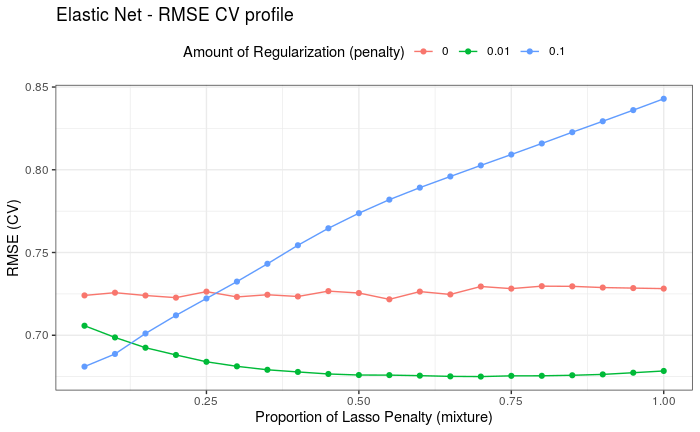

```r
enet_cv %>%
  collect_metrics() %>%
  filter(.metric == "rmse") %>%
  mutate(penalty = factor(penalty)) %>%
  ggplot(aes(mixture, mean, color = penalty)) +
  geom_point() +
  geom_line() +
  labs(x = "Proportion of Lasso Penalty (mixture)", y = "RMSE (CV)", color = "Amount of Regularization (penalty)",
       title = "Elastic Net - RMSE CV profile") +
  theme(legend.position = "top")
```

The error is relatively constant for the lower `penalty` values. For the largest `penalty` value (`0.1`), the error increases with increases lasso penalty.

Select the best model and store the training error:

```r
enet_best <- enet_cv %>%
  select_best("rmse")

# Store the training error:
rmse_train <- enet_cv %>%
  show_best("rmse") %>%
  pluck("mean", 1)
```

### Testing Data

Fit a model using all of the training data and apply it to the test data:

```r
# Finalize the workflow by updating it to use the best model:
final_wf <-
  workflow3.3 %>%
  finalize_workflow(enet_best)

# This extracts the parameters in the final model (this code is clunky, could probably be made simpler):
wf <- final_wf %>% workflows::pull_workflow_spec()
penalty <- wf$args$penalty[2] %>% as.character()
mixture <- wf$args$mixture[2] %>% as.character()

# Fit the final model using all of the training data and evaluate using the test data:
enet_fit_final <-
  final_wf %>%
  last_fit(splits)

# Store test error:
rmse_test <- enet_fit_final %>%
  collect_metrics() %>%
  filter(.metric == "rmse") %>%
  pluck(".estimate")
```

Store the training and test RMSE values and parameters:

```r
RMSE_TM <- rbind(RMSE_TM,
                 c(framework = "tidymodels",
                   engine = "glmnet",
                   model = "Elastic Net",
                   rmse_train = rmse_train,
                   rmse_test = rmse_test,
                   parameters = str_interp("penalty: ${penalty}; mixture: ${mixture}")))
```

### Use the predictions to make diagnostic plots

Collect the predictions from the final fit and make diagnostic plots:

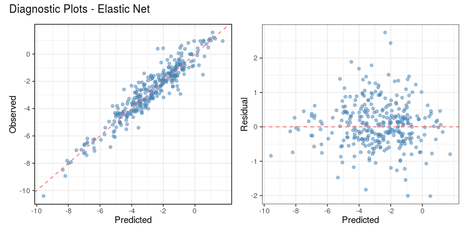

```r
preds <- enet_fit_final %>%
  collect_predictions() %>%
  mutate(residual = y - .pred)

p1 <- ggplot(preds) +
  geom_point(aes(.pred, y),
             color = "steelblue", alpha = 0.5) +
  geom_abline(color = "indianred1", linetype = "dashed") +
  scale_x_continuous("Predicted",
                     breaks = seq(-10, 0, by = 2)) +
  scale_y_continuous("Observed",
                     breaks = seq(-10, 0, by = 2))

p2 <- ggplot(preds) +
  geom_point(aes(.pred, residual),
             color = "steelblue", alpha = 0.5) +
  geom_hline(yintercept = 0,
             color = "indianred1", linetype = "dashed") +
  scale_x_continuous("Predicted",
                     breaks = seq(-10, 0, by = 2)) +
  scale_y_continuous("Residual")

p1 + p2 + plot_annotation(title = "Diagnostic Plots - Elastic Net")
```

## Metrics

View the training and test RMSE for each model:

```r
RMSE_TM %>%
  mutate(rmse_train = as.numeric(rmse_train),
         rmse_test = as.numeric(rmse_test)) %>%
  arrange(rmse_test)
```

| framework | engine | model | rmse_train | rmse_test | parameters |
| --- | --- | --- | --- | --- | --- |
| tidymodels | glmnet | Elastic Net | 0.6750 | 0.6621 | penalty: 0.01; mixture: 0.7 |
| tidymodels | glmnet | Lasso | 0.6754 | 0.6630 | penalty: 0.00749894209332456 |
| tidymodels | glmnet | Ridge Regression | 0.6854 | 0.6651 | penalty: 1e-04 |
| tidymodels | lm | Linear Regression | 0.7325 | 0.6950 | NA |
| tidymodels | mixOmics | PLS | 0.7049 | 0.7212 | num_comp: 15 |

[^1]: Kuhn M, Johnson K (2013). *Applied Predictive Modeling*. Springer.